# t-test

Sam Bogan

10/4/2021

# Summary

The $t$-test is a simple but powerful statistical tool for evaluating differences between values measured in two groups. Like all statistical tests, it relies on assumptions about the data you are using and becomes more reliable with larger sample sizes. This walk through will describe the basic structure and application of the $t$-test before walking you through R code for (i) plotting your data for visual inspection of between-group differences, (ii) testing whether your data match the $t$-test's assumptions, and (iii) applying and analyzing the results of a $t$-test.

# What you will need

1. The 't-test'folder that this .rmd is stored in and all of its original contents
2. A .csv copy of your group's protist carrying capacity data, formatted exactly as you see in the Protist_K_Data.csv file. An empty template for your group's protist K data is included in the 't-test' folder called 'My_Protist_K_Data.csv'

# What is a $t$-test?

$$t = \frac{\overline{x_{1}}-\overline{x_{2}}}
{\sqrt{(s^2(
\frac{1}{n_{1}} + \frac{1}{n_{2}}
))}}$$
$t$ = t statistic

$\overline{x_{i}}$ = mean of groups 1 or 2

$s$ = standard deviation of all observations

$n_{i}$ = sample size of groups 1 or 2

We may not go apple picking in Intro Bio, but we have generated some nifty data that lend themselves to a $t$-test. For example, we need to compare $K$ (carrying capacity) estimates between groups of protists can with and without competitors to see whether and how they are different. To apply a $t$-test to these data, let's first read it into R using the code chunk below. In these code chunks, '#' symbol denotes a description of what each line of code is doing.

# Import dataset to R

```r
# Read .csv file containing protist Kdata into R
Protist_K_Data <- read.csv("Protist_K_Data.csv")

# Let's look at how this data sheet is formatted
print(Protist_K_Data)
```

```
##    A_alone_K B_alone_K A_mixed_K B_mixed_K
## 1       3500      3680      1000      3000
## 2       3400      3680       800      3050
## 3       3300      3750      1300      3100
## 4       3650      3910      1150      3200
## 5       3600      3730      1050      2850
## 6       3550      3580       950      3050
## 7       3600      3660      1100      2950
## 8       3400      3730       800      2900
## 9       3350      3500      1100      2900
## 10      3450      3680       850      3050
## 11      3550      3910       750      3000
## 12      3650      3530      1050      2850
## 13      3550      3500       700      2800
## 14      3300      3830      1000      3200
## 15      3950      3710       750      3250
## 16      3450      3250       950      3250
## 17      3400      3680      1050      3200
## 18      3500      3750      1000      3000
```

Looking at the 'Protist_K_Data' data sheet, we can see that there are 4 columns. Each column has a short but unique name. You will import your own data ('My_Protist_K_Data.csv') into R later on in this walk through, which should be formatted exactly as the data sheet you see above. Next, we will plot and visually compare our K measurements between each group.

# Plotting data

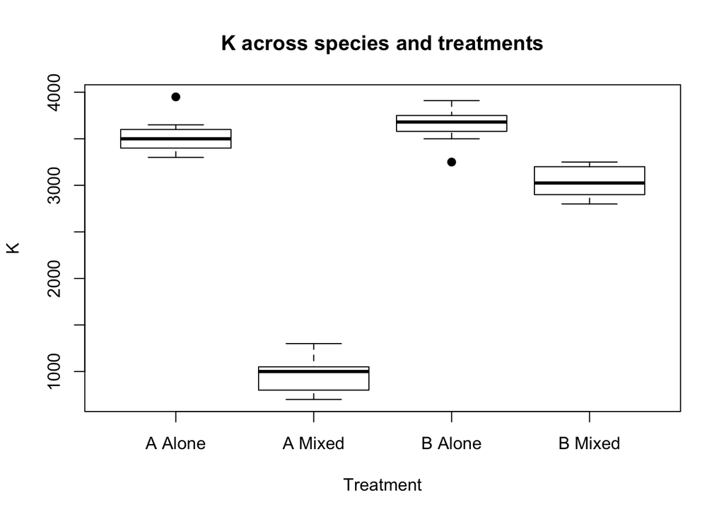

```r
## Don't worry about any of the code in this chunk
## Just look at the graph that it creates (below)

# Reformat datasheet for plotting
Plotting_Data <- rbind( data.frame(Species = "A",
                                   Mixed = "Alone",
                                   K = Protist_K_Data$A_alone_K),
                        data.frame(Species = "B",
                                   Mixed = "Alone",
                                   K = Protist_K_Data$B_alone_K),
                        data.frame(Species = "A",
                                   Mixed = "Mixed",
                                   K = Protist_K_Data$A_mixed_K),
                        data.frame(Species = "B",
                                   Mixed = "Mixed",
                                   K = Protist_K_Data$B_mixed_K))

# Create a variable combining species and treatment
Plotting_Data$Group <- as.factor(paste(Plotting_Data$Species,
                                       Plotting_Data$Mixed,
                                       sep = " "))

# Plot K values across all four treatment groups
plot(Plotting_Data$K ~ Plotting_Data$Group, main = "K across species and treatments",
     xlab = "Treatment", ylab = "K", pch = 19)
```

**Figure 1** | A box-whisker plot of $K$ estimates for species by treatment. Dark black lines depict median $K$. Boxes depict upper and lower quartiles. Tails depict the minima and maxima of $K$ distributions. Points depict outliers.

It looks like there are some distinct differences among treatment groups. For example, competition seems to have a large effect on $K$ in both A and B, with A exhibit the greatest reduction in $K$ under in the mixed treatment (Fig. 1). We will perform a few $t$-tests to see if $K$ in these groups possess significantly different means. First, we must check to see if our data meet the assumptions of a $t$-test.

# Checking for normal distribution

$t$-tests assume several things about the nature of your data. One of these assumptions is that your data are normally distributed, meaning the histogram of frequency for $K$ values exhibits a bell shaped curve with a mean and equal standard deviations in the postive and negative directions from that mean. Below is an example of a normally distributed histogram (blue) for a hypothetical value called '$x$' (Fig. 2).

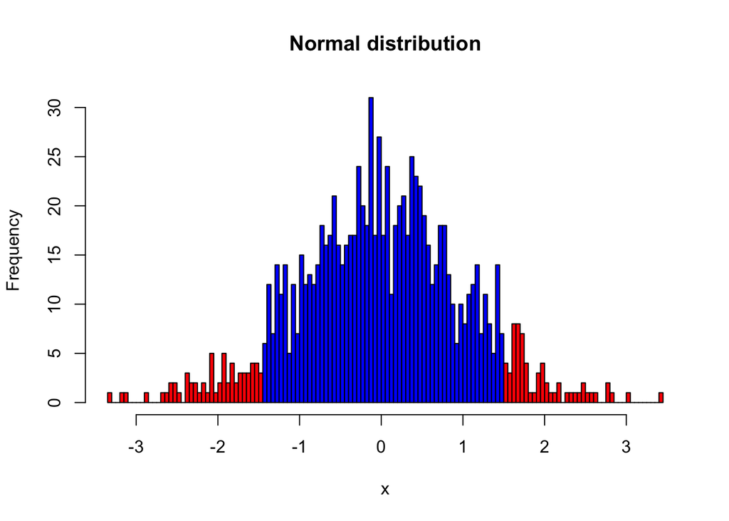

```r
## Don't worry about any of the code in this chunk
## Just look at the graph that it creates (below)

# Simulate normal and skewed distributions
norm_data <- scale(rnorm(1000))
h_norm <- hist(norm_data, breaks = 100, plot = FALSE)

# Plot the two distributions
plot(h_norm, col = ifelse(abs(h_norm$breaks) < 1.5, 4, 2),
     main = "Normal distribution",
     xlab = "x")
```

Not all data that you analyze will be normally distributed. Below is a histogram of simulated data that exhibit a skewed, non-normal distribution. These data would not meet the assumption of normality necessary to conduct a $t$-test (Fig. 3).

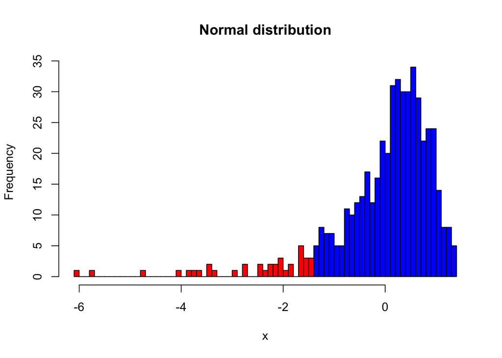

```r
## Don't worry about any of the code in this chunk
## Just look at the graph that it creates (below)

# Simulate normal and skewed distributions
norm_skew <- scale(log(rnorm(1000)))
h_skew <- hist(norm_skew, breaks = 100, plot = FALSE)

# Plot the two distributions
plot(h_skew, col = ifelse(abs(h_skew$breaks) < 1.5, 4, 2),
     main = "Normal distribution",
     xlab = "x")
```

Let's take at the distribution of our own data. Since there are noticeable differences between species and treatment groups, a histogram of $K$ is going to look like back of a stegasaurus. We can get around this issue by 'scaling' our data, where we set the mean of each group to 0 and transform $K$ into standard deviations of the mean. This may sound complicated, but it is simply a way of looking at the total distribution of data across groups with different means. After doing so, we can see that $K$ appears to be normally distributed across all groups (Fig. 4)!

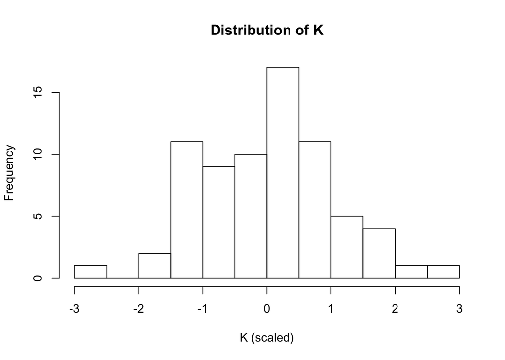

```r
# Scale K data
K_scaled <- rbind( scale( Protist_K_Data$A_alone_K),
       scale( Protist_K_Data$B_alone_K),
       scale(Protist_K_Data$A_mixed_K),
       scale(Protist_K_Data$B_mixed_K))

#Plot scaled K as a histogram
hist(K_scaled,
     main = "Distribution of K",
     xlab = "K (scaled)")
```

**Figure 4** | A histogram of scaled $K$ values from all species and treatment groups, meaning data were transformed such as that species and treatment group means = 0 and $K$ is expressed in standard deviations from the mean.

Looking at our data in this manner is great, and helps catch bugs or other issues with data. However, we can go beyond visual inspection and apply formal tests of normality. This cannot be done using raw data or scaled data. Rather, formal tests of normality rely on what are called "residuals": variation in a measurements that remains after explaining differences between groups do to factors (e.g., species or treatment group). We won't conduct a normality test in this walk through. If you are interested in learning about this method, please check out this excellent resource: https://www.datanovia.com/en/lessons/normality-test-in-r/.